# FFPE input recommendation for RNAseq

Yuanhang (Leo) Liu

26 April, 2022

# Data

You can load the Additional file 7.xlsx under the data direcotry. It contains sample-related metrics including pre-sequencing lab metrics and post-sequencing bioinformatics metrics:

1. ID: subject ID
2. FFPE.years.range: years of FFPE storage
3. Batch: sequencing batch
4. Group: sample group
5. RNA.Concentration.Qubit: pre-sequencing RNA concentration in Qubit (ng/ul)
6. Library.Concentration.Qubit: pre-capture library concentration in Qubit (ng/ul)
7. Reads.mapped.to.genes: # of reads mapped to genic regions
8. Mediancor: sample-wise median correlation of gene expression
9. TPM4: # of genes with transcript per million (TPM) >4
10. FILTER: PASS/FAIL filter defined by bioinformatics metrics
11. DV50: the percentage of RNA fragments > 50
12. DV100: the percentage of RNA fragments > 100 13: DV200: the percentage of RNA fragments > 200 14: RIN: RNA Integrity Number

# Installation

All analysis is performed in R. If you don’t have it, you can download R from [here](https://www.r-project.org/). Then you will need to install required R package if you don’t have them installed.

```r
install.packages("caret")
install.packages("readxl")
install.packages('rpart.plot')
install.packages('caTools')
```

load require R packages

```r
library('caret')
library('readxl')
library('rpart.plot')
library('caTools')
```

# Load data

load data and remove technical control samples as those will not be used in the model buliding.

```r
sampleinfo <- read_xlsx('Additional file 7.xlsx')
sampleinfo <- as.data.frame(sampleinfo)
sampleinfo <- sampleinfo[!sampleinfo$Group %in% c("FFPE technical control","FFzn technical control"),]
storage.mode(sampleinfo$RNA.Concentration.Qubit) <- 'numeric'
storage.mode(sampleinfo$Library.Concentration.Qubit) <- 'numeric'
str(sampleinfo)
```

```
## 'data.frame':    101 obs. of  14 variables:
##  $ ID                         : chr  "Subject1" "Subject10" "Subject11" "Subject12" ...
##  $ FFPE.years.range           : chr  "(40,50]" "(20,30]" "(40,50]" "(40,50]" ...
##  $ Batch                      : chr  "seqb2" "seqb2" "seqb6" "seqb5" ...
##  $ Group                      : chr  "Study sample" "Study sample" "Study sample" "Study sample" ...
##  $ RNA.Concentration.Qubit    : num  36.6 40.4 28.6 43 36.4 45.6 32.2 57.4 45.8 48 ...
##  $ Library.Concentration.Qubit: num  11.1 16.7 3.26 5 2.04 11.3 2.5 33.6 9.94 1.51 ...
##  $ Reads.mapped.to.genes      : num  64975951 50079831 60107873 94638980 82252813 ...
##  $ Mediancor                  : num  0.87 0.867 0.831 0.85 0.799 ...
##  $ TPM4                       : num  14498 13652 12715 13913 11896 ...
##  $ FILTER                     : chr  "PASS" "PASS" "PASS" "PASS" ...
##  $ DV50                       : chr  "87" "87" "87" "91" ...
##  $ DV100                      : chr  "28" "22" "22" "29" ...
##  $ DV200                      : chr  "2" "1" "2" "1" ...
##  $ RIN                        : chr  "2.6" "2.7" "2.6" "2.5" ...
```

# Define QC pass or fail based on bioinformatics metrics

```r
sampleinfo$FILTER <- ifelse(sampleinfo$Reads.mapped.to.genes  > 30*10^6 & sampleinfo$TPM4 > 12000 & sampleinfo$Mediancor > 0.75,'PASS','FAIL')
```

## Bulid decision tree model using pre-sequencing lab metrics

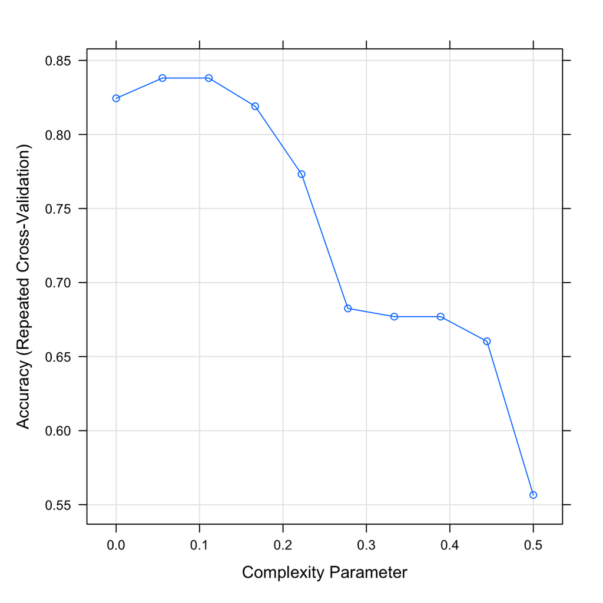

```r
set.seed(1234)
sample_split <- sample.split(Y = sampleinfo$FILTER, SplitRatio = 0.7)
train_set <- subset(x = sampleinfo, sample_split == TRUE)
test_set <- subset(x = sampleinfo, sample_split == FALSE)
modelfit <- train(FILTER ~ RNA.Concentration.Qubit + Library.Concentration.Qubit,method='rpart',data=train_set, trControl = trainControl(method = "repeatedcv",repeats = 3),tuneLength=10)
plot(modelfit)
```

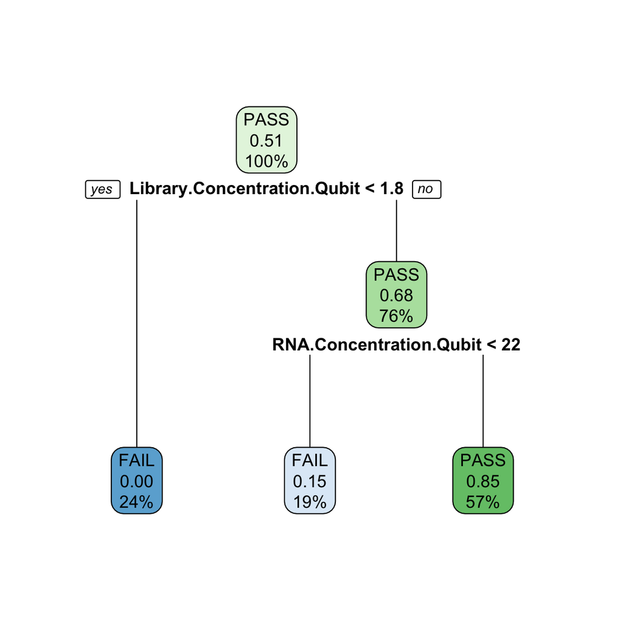

```r
rpart.plot::rpart.plot(modelfit$finalModel, extra = 106)
```